# Problem Set 3

Author

Jarrett Huff

Published

November 1, 2026

```r
library(tidyverse)
library(tidyquant)
library(fpp3)
library(knitr)
library(seasonal)
```

## 1. Time and Tsibbles

#retail_ts - Sourced manually from the U.S Census Bureau’s Monthly Retail Trade Survey via FRED. It tracks monthly retail trade and food services sales in millions of dollars. It contains two series stacked in long format (RSAFS) which are seasonally adjusted and (RSAFSNA) which are not seasonally adjusted. Its index is Month and its key is series_id

#can_gas - Sourced form the fpp3 package, tracking monthly natural gas production in Canada measured in billions of cubic meters from Jan 1960 to Feb 2005. Its index is Month and it has no key since it contains a single univariate series.

```r
# Read raw FRED retail sales CSV
retail_raw <- read_csv(
  "data/fredgraph.csv",
  na = ".",
  col_types = cols(
    observation_date = col_date(format = "%Y-%m-%d"),
    RSAFS = col_double(),
    RSAFSNA = col_double()
  )
)

# Reshape to long format
retail_raw_long <- retail_raw |>
  select(observation_date, RSAFS, RSAFSNA) |>
  pivot_longer(
    cols = c(RSAFS, RSAFSNA),
    names_to = "series_id",
    values_to = "sales"
  )

# Build retail_ts tsibble
retail_ts <- retail_raw_long |>
  mutate(Month = yearmonth(observation_date)) |>
  as_tsibble(index = Month, key = series_id)

# Create working copy of Canadian gas
can_gas <- canadian_gas |>
  select(Month, Volume)
```

## Gap Checks

```r
has_gaps(retail_ts) |> kable(caption = "Gap Check: Retail Sales tsibble")
```

Gap Check: Retail Sales tsibble

| series_id | .gaps |
| --- | --- |
| RSAFS | FALSE |
| RSAFSNA | FALSE |

```r
has_gaps(can_gas) |> kable(caption = "Gap Check: Canadian Gas tsibble")
```

Gap Check: Canadian Gas tsibble

| .gaps |
| --- |
| FALSE |

## Monthly Production Averages

```r
can_gas_recent <- can_gas |>
  filter(Month >= yearmonth("1990 Jan")) |>
  mutate(
    year    = year(Month),
    month   = month(Month, label = TRUE),
    quarter = quarter(Month)
  )

can_gas_recent |>
  as_tibble() |>
  group_by(month) |>
  summarize(avg_volume = mean(Volume)) |>
  kable(digits = 2, caption = "Average Canadian Gas Production by Month (1990–Present)")
```

Average Canadian Gas Production by Month (1990–Present)

| month | avg_volume |
| --- | --- |
| Jan | 16.99 |
| Feb | 15.28 |
| Mar | 16.34 |
| Apr | 15.74 |
| May | 15.75 |
| Jun | 14.94 |
| Jul | 15.60 |
| Aug | 15.62 |
| Sep | 15.13 |
| Oct | 16.16 |
| Nov | 16.18 |
| Dec | 17.15 |

Highest Production month - Dec exhibits the highest average production volume due to winter heating demand.

Lowest Production Month - Jun exhibits the lowest average production volume.

## Quarterly Aggregation

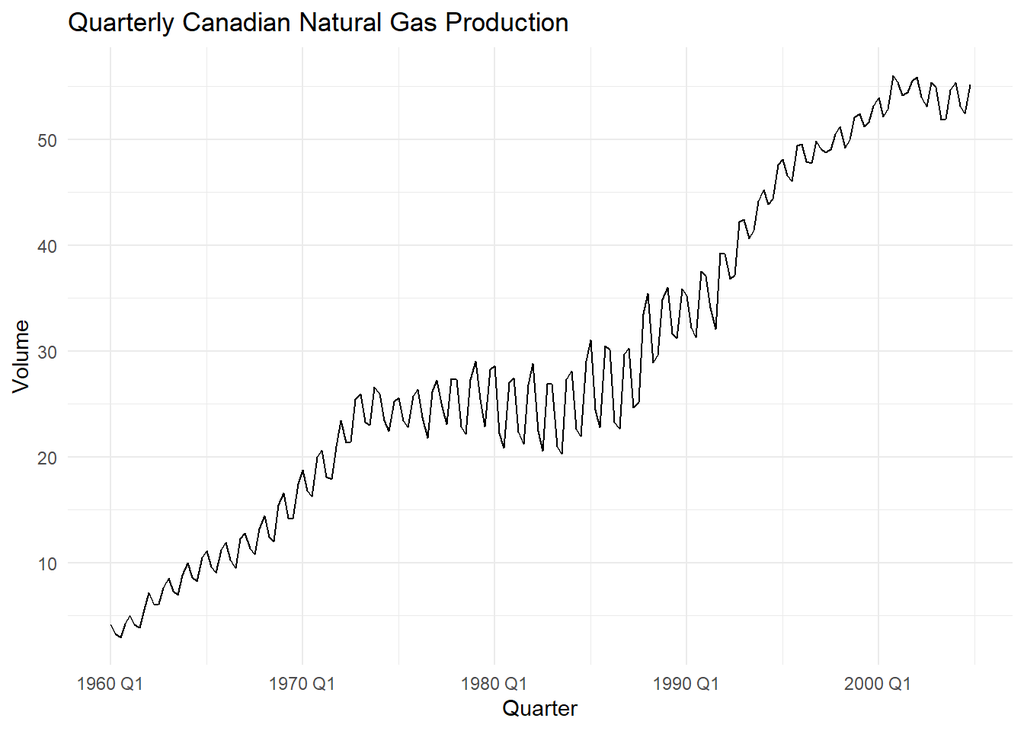

```r
can_gas_q <- can_gas |>
  filter(Month <= yearmonth("2004 Dec")) |>
  index_by(Quarter = yearquarter(Month)) |>
  summarize(Volume = sum(Volume))

can_gas_q |> autoplot(Volume) +
  labs(title = "Quarterly Canadian Natural Gas Production", x = "Quarter", y = "Volume") +
  theme_minimal()
```

Sum vs Mean - I used sum() rather than mean() because natural gas production is a flow variable representing cumulative volume produced over a time window, taking the average would yield average monthly production within a quarter rather than total quarterly output.

Seasonality - The quarterly series remains distinctly seasonal,exhibiting a clear repeating pattern across quarters.

## Visualizing Retail Sales and Gas Production

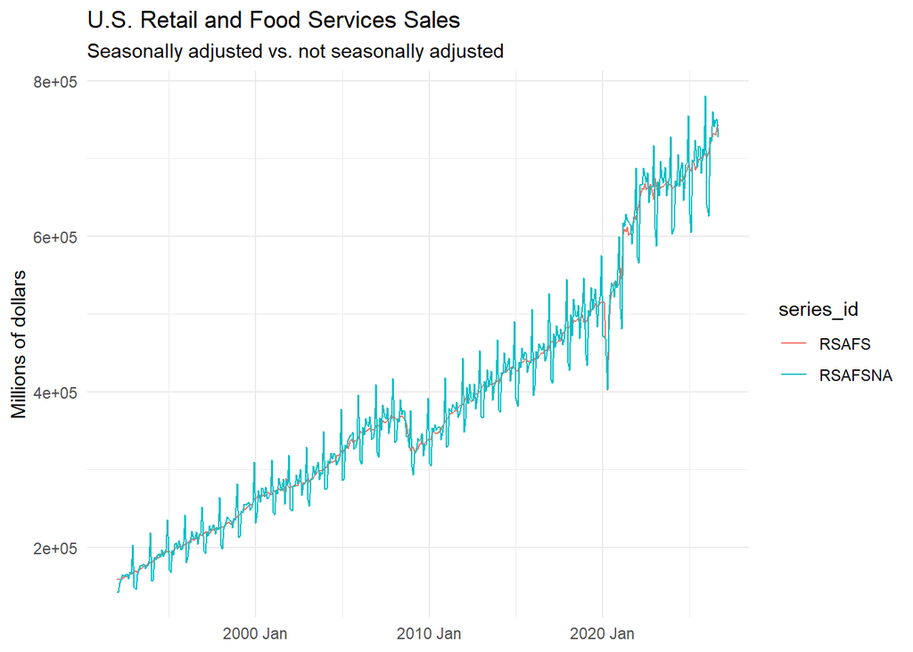

```r
retail_ts |>
  autoplot(sales) +
  labs(
    title = "U.S. Retail and Food Services Sales",
    subtitle = "Seasonally adjusted vs. not seasonally adjusted",
    x = NULL, y = "Millions of dollars", color = NULL
  ) +
  theme_minimal()
```

Seasonal Adjustment Analysis - The not seasonally adjusted (NSA) series exhibits an recurring inter year pattern, featuring a sharp surge Dec followed by an immediate drop in Jan. The seasonally adjusted (SA) series smooths out this calendar driven noise while keeping the long run macroeconomic trend and major recessionary contractions completely intact.

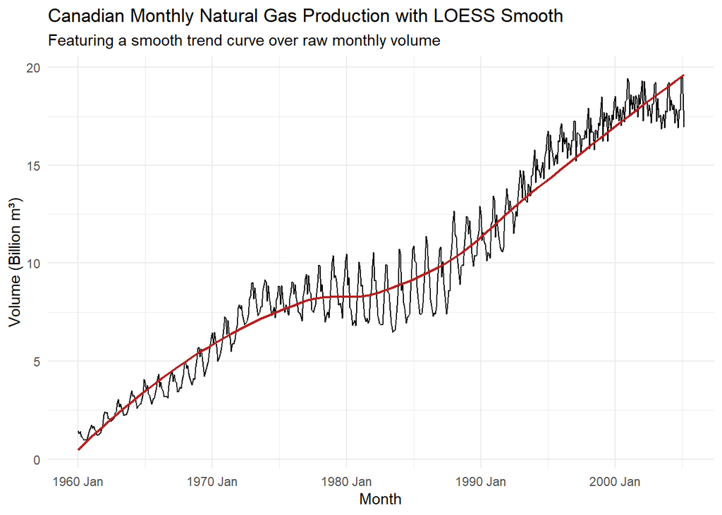

```r
can_gas |>
  autoplot(Volume) +
  geom_smooth(method = "loess", se = FALSE, color = "firebrick", linewidth = 0.8) +
  labs(
    title = "Canadian Monthly Natural Gas Production with LOESS Smooth",
    subtitle = "Featuring a smooth trend curve over raw monthly volume",
    x = "Month",
    y = "Volume (Billion m³)"
  ) +
  theme_minimal()
```

Layer explanation - I added a geom_smooth() layer to visibly highlight the overall secular trend in gas production independent of seasonal oscillations.

## 2. Transformations

## Log Transformations

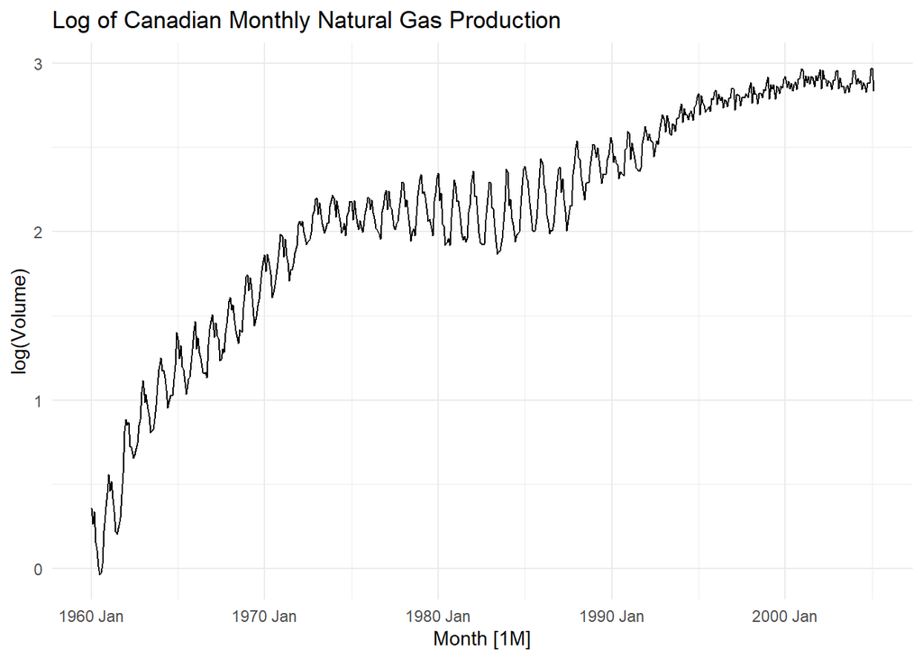

```r
can_gas <- can_gas |> mutate(log_volume = log(Volume))

can_gas |>
  autoplot(log_volume) +
  labs(title = "Log of Canadian Monthly Natural Gas Production", y = "log(Volume)") +
  theme_minimal()
```

Canadian gas log evaluation - Seasonal swings in raw gas production grow larger as overall volume increases through the 1970s and 1980s. Taking logarithms stabilizes the variance pf these seasonal oscillations, making constant percentage shifts appear as constant absolute movements, which benefits linear models.

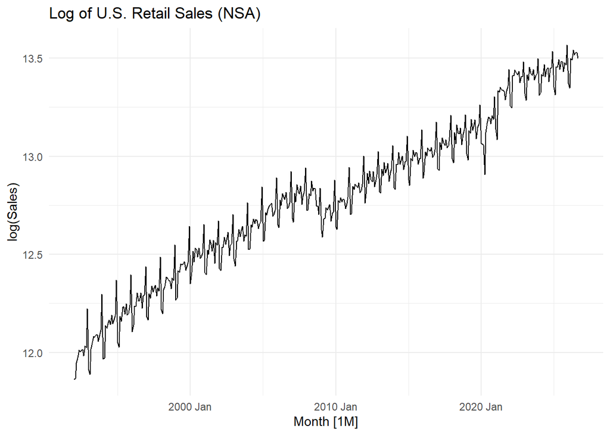

```r
retail_nsa_logged <- retail_ts |>
  filter(series_id == "RSAFSNA") |>
  mutate(log_sales = log(sales))

retail_nsa_logged |>
  autoplot(log_sales) +
  labs(title = "Log of U.S. Retail Sales (NSA)", y = "log(Sales)") +
  theme_minimal()
```

Retail sales log evaluation - The case for logging the NSA retail sales series is even stronger than for Canadian gas because retail sales display huge, multiplicative Dec holiday spikes that grow exponentially larger in absolute dollar terms over time.

## Growth Rates & Approximation

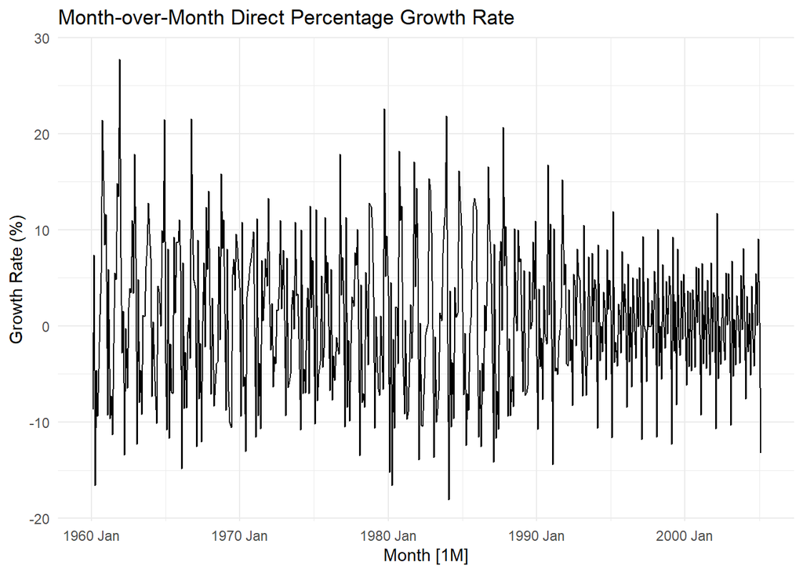

```r
can_gas <- can_gas |>
  mutate(
    growth_direct = 100 * difference(Volume) / lag(Volume),
    growth_logdiff = 100 * difference(log_volume),
    growth_gap = abs(growth_direct - growth_logdiff)
  )

can_gas |>
  autoplot(growth_direct) +
  labs(title = "Month-over-Month Direct Percentage Growth Rate", y = "Growth Rate (%)") +
  theme_minimal()
```

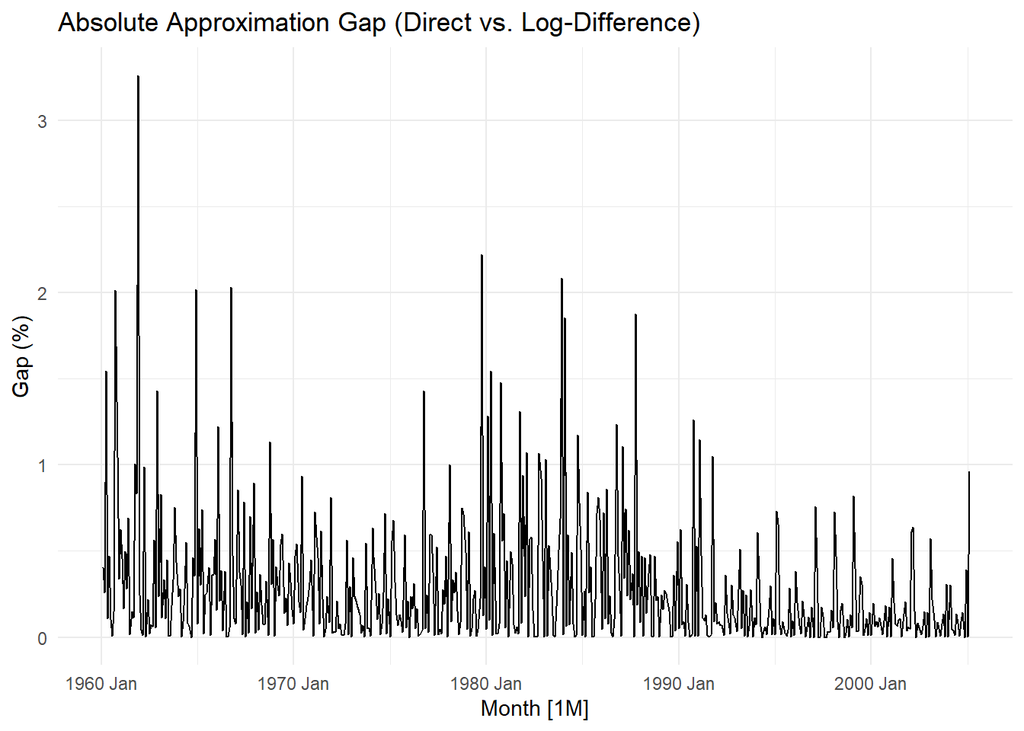

```r
can_gas |>
  autoplot(growth_gap) +
  labs(title = "Absolute Approximation Gap (Direct vs. Log-Difference)", y = "Gap (%)") +
  theme_minimal()
```

Approximation accuracy - The log difference approximation is extremely accurate in this context, with the absolute difference growth_gap remaining close to zero across almost all observations.

## SA vs NSA Growth Rates

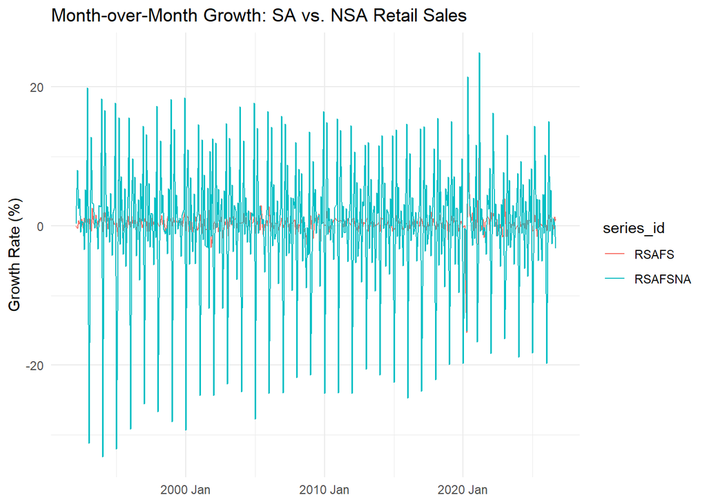

```r
retail_ts <- retail_ts |>
  group_by_key() |>
  mutate(growth_mom = 100 * difference(log(sales))) |>
  ungroup()

retail_ts |>
  autoplot(growth_mom) +
  labs(
    title = "Month-over-Month Growth: SA vs. NSA Retail Sales",
    x = NULL, y = "Growth Rate (%)", color = NULL
  ) +
  theme_minimal()
```

Growth Rate Comparison - The month over month growth rate of the NSA series is significantly noisier than that of the SA series, exhibiting massive, recurring spikes and drops every year. This extreme volatility is driven by predictable calendar events and holiday shopping cycles, such as massive Dec retail surges followed by sharp Jan contractions. In contrast, seasonal adjustment filters out this predictable intr year calendar noise, leaving the SA growth rate much smoother and better reflective of true underlying economic momentum.